# **Escuela Politécnica Nacional**

## **[Tarea 03] Ejercicios Unidad 01-B**

### **Nombre:** Luis Alexander Lema Delgado

### **Fecha:** 02/11/2025

### **Curso:** GR1CC

### **Repositorio:**

https://github.com/LuisALema/Metodos_Numericos_2025B/tree/main/Deberes/%5BTarea%2003%5D

**CONJUNTO DE EJERCICIOS 1.3**

**1. Utilice aritmética de corte de tres dígitos para calcular las siguientes sumas. Para cada parte, ¿Qué método es más preciso y por qué?**

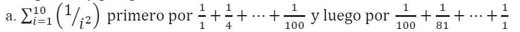

```python
import math
import decimal

def truncar(numero, digitos):

    factor = 10.0 ** digitos
    return math.floor(numero * factor) / factor

def suma_corte(terminos, digitos_corte=3):

    suma_acumulada = 0.0
    pasos_intermedios = []
    for termino in terminos:
        termino_truncado = truncar(termino, digitos_corte)
        suma_parcial_truncada = truncar(suma_acumulada + termino_truncado, digitos_corte)
        pasos_intermedios.append((termino_truncado, suma_parcial_truncada))
        suma_acumulada = suma_parcial_truncada
    return suma_acumulada, pasos_intermedios

# Calcular los términos de la serie
terminos = [1.0 / (i**2) for i in range(1, 11)]

# Método 1: Suma hacia adelante
print("Suma ascendente:")
error_ascendente, pasos_a = suma_corte(terminos)
for termino, suma_parcial in pasos_a:
    print(f"Término truncado: {termino:.3f}, Suma parcial truncada: {suma_parcial:.3f}")
print(f"Resultado de la suma ascendente con truncamiento: {error_ascendente:.3f}\n")

# Método 2: Suma hacia atrás
print("Suma descendente:")
error_descendente, pasos_descendente = suma_corte(list(reversed(terminos)))
for termino, suma_parcial in pasos_descendente:
    print(f"Término truncado: {termino:.3f}, Suma parcial truncada: {suma_parcial:.3f}")
print(f"Resultado de la suma descendente con truncamiento: {error_descendente:.3f}")

# Determinar qué método es más preciso
decimal.getcontext().prec = 10
suma = sum(decimal.Decimal(1) / decimal.Decimal(i**2) for i in range(1, 11))

print(f"\nSuma con mayor precisión para comparación: {float(suma):.6f}")
print(f"Error absoluto de la suma ascedente: {abs(error_ascendente - float(suma)):.6f}")
print(f"Error absoluto de la suma descendente: {abs(error_descendente - float(suma)):.6f}")

if abs(error_descendente - float(suma)) < abs(error_ascendente - float(suma)):
    print("\nLa suma descendente es más precisa con aritmética de corte de tres dígitos.")
else:
    print("\nLa suma ascendente es más precisa con aritmética de corte de tres dígitos.")
```

```
Suma ascendente:
Término truncado: 1.000, Suma parcial truncada: 1.000
Término truncado: 0.250, Suma parcial truncada: 1.250
Término truncado: 0.111, Suma parcial truncada: 1.361
Término truncado: 0.062, Suma parcial truncada: 1.423
Término truncado: 0.040, Suma parcial truncada: 1.463
Término truncado: 0.027, Suma parcial truncada: 1.490
Término truncado: 0.020, Suma parcial truncada: 1.510
Término truncado: 0.015, Suma parcial truncada: 1.525
Término truncado: 0.012, Suma parcial truncada: 1.537
Término truncado: 0.010, Suma parcial truncada: 1.547
Resultado de la suma ascendente con truncamiento: 1.547

Suma descendente:
Término truncado: 0.010, Suma parcial truncada: 0.010
Término truncado: 0.012, Suma parcial truncada: 0.022
Término truncado: 0.015, Suma parcial truncada: 0.037
Término truncado: 0.020, Suma parcial truncada: 0.056
Término truncado: 0.027, Suma parcial truncada: 0.083
Término truncado: 0.040, Suma parcial truncada: 0.123
Término truncado: 0.062, Suma parcial truncada: 0.185
Término truncado: 0.111, Suma parcial truncada: 0.296
Término truncado: 0.250, Suma parcial truncada: 0.546
Término truncado: 1.000, Suma parcial truncada: 1.546
Resultado de la suma descendente con truncamiento: 1.546

Suma con mayor precisión para comparación: 1.549768
Error absoluto de la suma ascedente: 0.002768
Error absoluto de la suma descendente: 0.003768

La suma ascendente es más precisa con aritmética de corte de tres dígitos.
```

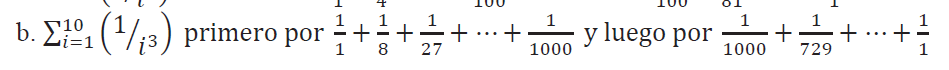

```python
# Calcular los términos de la serie para el literal b
terminos_b = [1.0 / (i**3) for i in range(1, 11)]

# Método 1: Suma hacia adelante para el literal b
print("Literal b: Suma ascendente:")
resultado_ascendente_b, pasos_b = suma_corte(terminos_b)
for termino, suma_parcial in pasos_b:
    print(f"Término truncado: {termino:.3f}, Suma parcial truncada: {suma_parcial:.3f}")
print(f"Resultado de la suma ascendente con corte a 3 dígitos: {resultado_ascendente_b:.3f}\n")

# Método 2: Suma descendete para el literal b
print("Literal b: Suma descendente:")
resultado_descendente_b, pasos_b_descendente = suma_corte(list(reversed(terminos_b)))
for termino, suma_parcial in pasos_b_descendente:
    print(f"Término truncado: {termino:.3f}, Suma parcial truncada: {suma_parcial:.3f}")
print(f"Resultado de la suma descendente con corte a 3 dígitos: {resultado_descendente_b:.3f}")

# Determinar qué método es más preciso para el literal b
decimal.getcontext().prec = 10
suma_b = sum(decimal.Decimal(1) / decimal.Decimal(i**3) for i in range(1, 11))

print(f"\nSuma con mayor precisión para comparación: {float(suma_b):.6f}")
error_b = abs(resultado_ascendente_b - float(suma_b))
error_b_descendente = abs(resultado_descendente_b - float(suma_b))
print(f"Error absoluto de la suma ascendente: {error_b:.6f}")
print(f"Error absoluto de la suma descendente: {error_b_descendente:.6f}")

if error_b_descendente < error_b:
    print("\nPara el literal b, la suma descendente es más precisa con aritmética de corte de tres dígitos.")
else:
    print("\nPara el literal b, la suma ascendente es más precisa con aritmética de corte de tres dígitos.")
```

```
Literal b: Suma ascendente:
Término truncado: 1.000, Suma parcial truncada: 1.000
Término truncado: 0.125, Suma parcial truncada: 1.125
Término truncado: 0.037, Suma parcial truncada: 1.162
Término truncado: 0.015, Suma parcial truncada: 1.176
Término truncado: 0.008, Suma parcial truncada: 1.184
Término truncado: 0.004, Suma parcial truncada: 1.188
Término truncado: 0.002, Suma parcial truncada: 1.190
Término truncado: 0.001, Suma parcial truncada: 1.190
Término truncado: 0.001, Suma parcial truncada: 1.190
Término truncado: 0.001, Suma parcial truncada: 1.190
Resultado de la suma ascendente con corte a 3 dígitos: 1.190

Literal b: Suma descendente:
Término truncado: 0.001, Suma parcial truncada: 0.001
Término truncado: 0.001, Suma parcial truncada: 0.002
Término truncado: 0.001, Suma parcial truncada: 0.003
Término truncado: 0.002, Suma parcial truncada: 0.005
Término truncado: 0.004, Suma parcial truncada: 0.009
Término truncado: 0.008, Suma parcial truncada: 0.017
Término truncado: 0.015, Suma parcial truncada: 0.032
Término truncado: 0.037, Suma parcial truncada: 0.069
Término truncado: 0.125, Suma parcial truncada: 0.194
Término truncado: 1.000, Suma parcial truncada: 1.194
Resultado de la suma descendente con corte a 3 dígitos: 1.194

Suma con mayor precisión para comparación: 1.197532
Error absoluto de la suma ascendente: 0.007532
Error absoluto de la suma descendente: 0.003532

Para el literal b, la suma descendente es más precisa con aritmética de corte de tres dígitos.
```

**2. La serie de Maclaurin para la función arcotangente converge para −1<𝑥≤1 y está dada por**

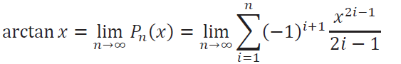

```python
def calculo_terminos_a():

    tolerancia = 1e-3
    suma = 0.0
    n = 1

    while True:
        # Calcula el término n-ésimo de la serie
        termino = (-1)**(n + 1) / (2 * n - 1)
        suma += termino
        pi_aproximado = 4 * suma

        # Calcula el error absoluto
        error = abs(pi_aproximado - math.pi)

        # Verifica si se alcanzó la precisión deseada
        if error < tolerancia:
            print(f"Se necesitan {n} términos para alcanzar |4P_n(1) - π| < 10^-3")
            print(f"Valor aproximado de π: {pi_aproximado}")
            print(f"Error absoluto: {error:.6f}")
            print(f"Valor real de π: {math.pi:.6f}")
            return
        n += 1
calculo_terminos_a()
```

```
Se necesitan 1000 términos para alcanzar |4P_n(1) - π| < 10^-3
Valor aproximado de π: 3.140592653839794
Error absoluto: 0.001000
Valor real de π: 3.141593
```

**b. El lenguaje de programación C++ requiere que el valor de 𝜋 se encuentre dentro de 10^−10. ¿Cuántos términos de la serie se necesitarían sumar para obtener este grado de precisión?**

```python
def calcular_terminos_B(tolerancia=1e-10, max_terminos=10**7):

    suma = 0.0
    n = 1
    while n <= max_terminos:
        termino = (-1)**(n + 1) / (2 * n - 1)
        suma += termino
        pi_aproximado = 4 * suma
        error = abs(pi_aproximado - math.pi)

        if error < tolerancia:
            print(f"Se necesitan {n} términos para alcanzar |4P_n(1) - π| < {tolerancia}")
            print(f"Valor aproximado de π: {pi_aproximado:.12f}")
            print(f"Error absoluto: {error:.1e}")
            print(f"Valor real de π: {math.pi:.12f}")
            return
        n += 1
    print(f"No se alcanzó la precisión deseada ({tolerancia}) después de {max_terminos} términos.")

# Calcular el número de términos necesarios para una tolerancia de 1e-10
calcular_terminos_B(tolerancia=1e-10)
```

```
No se alcanzó la precisión deseada (1e-10) después de 10000000 términos.
```

**Determine el número de términos que se deben sumar para garantizar una aproximación 𝜋 dentro de 10^−3.**

```python
# definir la función arctan que calcula el valor de arctan(x) usando la serie de Taylor
def arctan(valor_x, cantidad_terminos):

  resultado = 0.0
  for indice in range(cantidad_terminos):
    numerador = ((-1) ** indice) * (valor_x ** (2 * indice + 1))
    denominador = 2 * indice + 1
    resultado += numerador / denominador
  return resultado

# Calcular el número de términos necesarios para aproximar pi con un error menor a 1e-3
def aproximado_pi(margen_error):

  num_terminos = 1
  pi_estimado = 4 * (4 * arctan(1/5, num_terminos) - arctan(1/239, num_terminos))

  while abs(pi_estimado - math.pi) > margen_error:
    num_terminos += 1
    pi_estimado = 4 * (4 * arctan(1/5, num_terminos) - arctan(1/239, num_terminos))

  return num_terminos, pi_estimado

# Se usa la variable error_max ya definida en el notebook
error_max = 1e-3
n_terminos_necesarios, pi_calculado_nuevo = aproximado_pi(error_max)

print(f"Número de términos requeridos: {n_terminos_necesarios}")
print(f"Valor de pi estimado: {pi_calculado_nuevo}")
print(f"Error absoluto: {abs(pi_calculado_nuevo - math.pi)}")
```

```
Número de términos requeridos: 2
Valor de pi estimado: 3.1405970293260603
Error absoluto: 0.0009956242637327861
```

**4. Compare los siguientes tres algoritmos. ¿Cuándo es correcto el algoritmo de la parte 1a?**

**Algoritmo A**

```python
def algoritmo_a(n, x):
    producto = 0
    for i in range(n):
        producto *= x[i]
    return producto
```

**Algoritmo B**

```python
def algoritmo_b(n, x):
    producto = 1
    for i in range(n):
        producto *= x[i]
    return producto
```

**Algoritmo C**

```python
def algoritmo_c(n, x):
    producto = 1
    for i in range(n):
        if x[i] == 0:
            producto = 0
            return producto  # Terminación temprana si se encuentra un 0
        producto *= x[i]
    return producto
```

```python
# Casos de prueba
casos_prueba = [
    (3, [2, 3, 4]),      # Producto normal
    (5, [-1, 2, -3, 4, -5]), # Números negativos
    (2, [2.5, 4.0])     # Números de punto flotante
]
```

```python
print("Resultados de los algoritmos:")
for n, x in casos_prueba:
    print(f"\nEntrada: n={n}, x={x}")
    resultado_a = algoritmo_a(n, list(x))
    resultado_b = algoritmo_b(n, list(x))
    resultado_c = algoritmo_c(n, list(x))
    resultado_correcto = math.prod(x) if x else 1 # Producto correcto

    print(f"  Algoritmo a: {resultado_a}")
    print(f"  Algoritmo b: {resultado_b}")
    print(f"  Algoritmo c: {resultado_c}")
    print(f"  Resultado Correcto: {resultado_correcto}")
```

```
Resultados de los algoritmos:

Entrada: n=3, x=[2, 3, 4]
  Algoritmo a: 0
  Algoritmo b: 24
  Algoritmo c: 24
  Resultado Correcto: 24

Entrada: n=5, x=[-1, 2, -3, 4, -5]
  Algoritmo a: 0
  Algoritmo b: -120
  Algoritmo c: -120
  Resultado Correcto: -120

Entrada: n=2, x=[2.5, 4.0]
  Algoritmo a: 0.0
  Algoritmo b: 10.0
  Algoritmo c: 10.0
  Resultado Correcto: 10.0
```

```python
# definir la función que calcula el número de multiplicaciones y sumas
def calcular_conteo(limite):
    producto_total = 0
    adiciones_totales = 0
    indice_externo = 1
    while indice_externo <= limite:
        indice_interno = 1
        while indice_interno <= indice_externo:
            producto_total += 1
            if indice_externo > 1 or indice_interno > 1:
                adiciones_totales += 1
            indice_interno += 1
        indice_externo += 1
    return producto_total, adiciones_totales

# Ejemplo
valor_n = 5
productos, adiciones = calcular_conteo(valor_n)
print(f"Para un límite de {valor_n}:")
print(f"Cantidad total de multiplicaciones: {productos}")
print(f"Número total de sumas: {adiciones}")
```

```
Para un límite de 5:
Cantidad total de multiplicaciones: 15
Número total de sumas: 14
```

**b. Modifique la suma en la parte a) a un formato equivalente que reduzca el número de cálculos.**

```python
# Definir la función que calcula el número de multiplicaciones y sumas de manera optimizada
def calcular_conteo(limite):
    # Calcular el total de multiplicaciones usando la fórmula
    producto_total = (limite * (limite + 1)) // 2
    # Calcular el total de sumas usando la fórmula
    adiciones_totales = ((limite - 1) * limite) // 2
    return producto_total, adiciones_totales

# Ejemplo
valor_n = 5
productos, adiciones = calcular_conteo(valor_n)
print(f"Para un límite de {valor_n}:")
print(f"Cantidad total de multiplicaciones: {productos}")
print(f"Número total de sumas: {adiciones}")
```

```
Para un límite de 5:
Cantidad total de multiplicaciones: 15
Número total de sumas: 10
```

### **Discusiones**

```python
# definir la suma de la serie en orden inverso
def suma_inversa(x):
    suma_total = 0
    # Recorrer la lista en orden inverso
    for i in range(len(x)-1, -1, -1):
        suma_total += x[i]
    return suma_total

# Ejemplo
x = [3, 5.2, 4, 8.6, 2.5]  # Ejemplo de serie
resultado = suma_inversa(x)
print(f"La suma de la serie en orden inverso es: {resultado}")
```

```
La suma de la serie en orden inverso es: 23.3
```

**Construya un algoritmo con entrada 𝑎, 𝑏, 𝑐 y salida x_1 y x_2 que calcule las raíces x_1 y x_2 (que pueden ser iguales con conjugados complejos) mediante la mejor fórmula para cada raíz.**

```python
def obtener_raices(a, b, c):
    # Calcular el discriminante
    discriminante = b**2 - 4*a*c

    # Evaluar el discriminante para determinar el tipo de raíces
    if discriminante > 0:
        # Dos raíces reales distintas
        if b > 0:
            raiz1 = (-b - discriminante**0.5) / (2*a)
            raiz2 = (2*c) / (-b - discriminante**0.5)
        else:
            raiz1 = (-b + discriminante**0.5) / (2*a)
            raiz2 = (2*c) / (-b + discriminante**0.5)
        return f"Raíces reales distintas: x1 = {raiz1}, x2 = {raiz2}"

    elif discriminante == 0:
        # Una raíz real doble
        raiz = -b / (2*a)
        return f"Raíz doble y real: x = {raiz}"

    else:
        # Raíces complejas
        parte_real = -b / (2*a)
        parte_imaginaria = (abs(discriminante)**0.5) / (2*a)
        return f"Raíces complejas: x1 = {parte_real} + {parte_imaginaria}i, x2 = {parte_real} - {parte_imaginaria}i"

# Ejemplo
print(obtener_raices(1, -5, 3))  # Raíces reales distintas
print(obtener_raices(1, -4, 2))  # Raíz doble
print(obtener_raices(1, 3, 5))   # Raíces complejas
```

```
Raíces reales distintas: x1 = 4.302775637731995, x2 = 0.6972243622680053
Raíces reales distintas: x1 = 3.414213562373095, x2 = 0.585786437626905
Raíces complejas: x1 = -1.5 + 1.6583123951777i, x2 = -1.5 - 1.6583123951777i
```

**3. Suponga que**

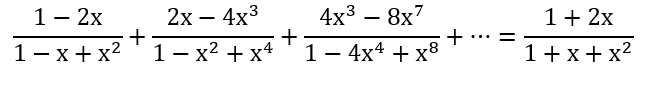

**para 𝑥<1 y si 𝑥=0.25. Escriba y ejecute un algoritmo que determine el número de términos necesarios en el lado izquierdo de la ecuación de tal forma que el lado izquierdo difiera del lado derecho en menos de 10^−6.**

```python
# calcular el número de términos necesarios para aproximar la suma de la serie
def calcular_termino(x, n):
    # Numerador
    pow_n = 2**n
    pow_n1 = 2**(n+1)
    numerador = (2**n) * (x**(pow_n - 1)) - (2**(n+1)) * (x**(pow_n1 - 1))
    # Denominador
    denominador = 1 - x**pow_n + x**pow_n1
    return numerador / denominador

# calcular la suma de la serie usando el número de términos necesarios
def calcular_suma(x, tolerancia=1e-6, max_iter=1000):
    suma = 0.0
    n = 0
    valor_derecho = (1 + 2*x) / (1 + x + x**2)
    while True:
        termino = calcular_termino(x, n)
        suma += termino
        diferencia = abs(suma - valor_derecho)
        if diferencia < tolerancia:
            break
        n += 1
        if n > max_iter:
            print("No se alcanzó la tolerancia en el máximo número de iteraciones.")
            break
    return n+1, suma  # n+1 términos sumados

# Ejemplo
if __name__ == "__main__":
    x = 0.25
    tolerancia = 1e-6
    terminos_usados, suma_aproximada = calcular_suma(x, tolerancia)
    valor_derecho = (1 + 2*x) / (1 + x + x**2)
    print(f"Número de términos necesarios: {terminos_usados}")
    print(f"Suma aproximada de la serie: {suma_aproximada:.10f}")
    print(f"Valor del lado derecho exacto: {valor_derecho:.10f}")
```

```
Número de términos necesarios: 4
Suma aproximada de la serie: 1.1428571280
Valor del lado derecho exacto: 1.1428571429
```